# A2_Antonio_Rolda_Andrade

# 3.1 Preparación de los datos

```r
# Agregamos variable HighInequality
# Valores que toma regime son: ELectoral Autocracy, Closed Autocracy, Electoral Democracy, Liberal Democracy

# 1. Preparación de los datos: Filtrar 2018 y crear la variable HighInequality
df_proporciones <- worldSustainabiltyDataSet %>%
  filter(Year == 2018) %>%
  filter(!is.na(GINI) & !is.na(Regime)) %>%
  mutate(
    HighInequality = ifelse(GINI > 40, 1, 0) # Crear la variable HighInequality (1 si GINI > 40, 0 en caso contrario)
  )

# 2. Calcular la proporción

tabla_proporcion_regimen <- df_proporciones %>%
  # Agrupar por el tipo de régimen
  group_by(Regime) %>%
  # Calcular la proporción de países con HighInequality = 1
  summarise(
    Total_Paises = n(),
    Paises_Alta_Desigualdad = sum(HighInequality),
    Proporcion_Alta_Desigualdad = mean(HighInequality) * 100 # Multiplicamos para %
  ) %>%
  # Desagrupar y renombrar columnas para la tabla final (mayor legilibilidad)
  ungroup() %>%
  select(
    Regimen = Regime,
    `Países` = Total_Paises,
    `Países GINI > 40` = Paises_Alta_Desigualdad,
    `Proporción (%)` = Proporcion_Alta_Desigualdad
  )

# Mostrar la tabla de resultados
print(tabla_proporcion_regimen)
```

```
## # A tibble: 4 × 4
##   Regimen             Países `Países GINI > 40` `Proporción (%)`
##   <chr>                <int>              <dbl>            <dbl>
## 1 Closed Autocracy         4                  0              0
## 2 Electoral Autocracy     13                  5             38.5
## 3 Electoral Democracy     27                 11             40.7
## 4 Liberal Democracy       20                  2             10
```

## 3.2 Hipótesis

Teniendo la pregunta PR3, extraemos lo siguiente:

- Población 1: Proporción desigualdad régimen democrático
- Poblacion 2: Proporción de países régimen autocrático
- Hipótesis Nula (h0): prop1 = prop2
- Hipótesis Alternativa (h1): prop1 != prop2

## 3.3 Test

Estamos tratando con proporciones independientes y con covarianza desconocida pero estimable, dado que : - Son independientes puesto que no estamos tratando de relacionar el mismo país en distintas franjas de tiempo, si no que tenemos una compartiva con múltiples países entre sí. - La varianza es desconocida puesto que estamos usando datos muestrales para estimar las proporciones poblacionales.  
Además, el test a realizar ha de ser bilateral puesto que necesitamos probar que las proporciones no sean iguales.

Por tanto, ya que tenemos unas poblaciones de tamaño reducido, por lo que usaremos el test de Fisher.

## 3.4 Aplicación del test

Al estar en el caso de una proporción no es necesario realizar test de homocedasticidad, puesto que la varianza de la proporción esta ligada a ella misma.

```r
# Tenemos que recalcular los datos, ya que a nivel visual nos interesa mostrar las distintas democracias y autocracias
# A nivel de cálculo solo diferenciaremos entre democracias y autocracias.


# 1. Cambiamos los datos en regime para que sea binario
df_proporciones <- df_proporciones %>%
  mutate(
    Regime_Binario = case_when(
      Regime %in% c("Closed Autocracy", "Electoral Autocracy") ~ "Autocratic",
      Regime %in% c("Electoral Democracy", "Liberal Democracy") ~ "Democratic"
    )
  )

# 2. Recalcular las sumas de éxitos y totales para los 2 grupos (preparación para el Z Test)
datos_test_fisher <- df_proporciones %>%
  filter(Regime_Binario %in% c("Democratic", "Autocratic")) %>%
  group_by(Regime_Binario) %>%
  summarise(
    Exitos = sum(HighInequality),
    N_Total = n()
  ) %>%
  ungroup()

print(datos_test_fisher)
```

```
## # A tibble: 2 × 3
##   Regime_Binario Exitos N_Total
##   <chr>           <dbl>   <int>
## 1 Autocratic          5      17
## 2 Democratic         13      47
```

```r
# 3. Extraer los datos:
exitos_dem <- datos_test_fisher %>% filter(Regime_Binario == "Democratic") %>% pull(Exitos)
n_dem <- datos_test_fisher %>% filter(Regime_Binario == "Democratic") %>% pull(N_Total)

exitos_aut <- datos_test_fisher %>% filter(Regime_Binario == "Autocratic") %>% pull(Exitos)
n_aut <- datos_test_fisher %>% filter(Regime_Binario == "Autocratic") %>% pull(N_Total)

# 1. Definir la matriz de contingencia (Filas: Tipo de Régimen; Columnas: Desigualdad)
# Relleno de la matriz: [A_Exitos, A_Fracasos; D_Exitos, D_Fracasos]
matriz_fisher <- matrix(
  c(exitos_aut, n_aut - exitos_aut, # Autocrático: Éxitos y Fracasos
    exitos_dem, n_dem - exitos_dem), # Democrático: Éxitos y Fracasos
  nrow = 2,
  byrow = TRUE # Indica como introducimos por filas (primero Autocrático, luego Democrático)
)

# Nombrar las dimensiones (Mayor legilibilidad)
rownames(matriz_fisher) <- c("Autocratic", "Democratic")
colnames(matriz_fisher) <- c("GINI > 40 (Exito)", "GINI <= 40 (Fracaso)")

print(matriz_fisher)
```

```
##            GINI > 40 (Exito) GINI <= 40 (Fracaso)
## Autocratic                 5                   12
## Democratic                13                   34
```

```r
# 4. Realizamos el cálculo

test_fisher_resultado <- fisher.test(
  matriz_fisher,
  alternative = "two.sided" # Ya que el test es bilateral
)

print(test_fisher_resultado)
```

```
##
##  Fisher's Exact Test for Count Data
##
## data:  matriz_fisher
## p-value = 1
## alternative hypothesis: true odds ratio is not equal to 1
## 95 percent confidence interval:
##  0.2499271 4.2052001
## sample estimates:
## odds ratio
##   1.088265
```

## 3.5 Desarrollo

Debido a la dificultad que presenta el cálculo de forma manual del test de Fisher, realizaremos dicho cálculo mediante el test Z.

```r
# H0: p1 = p2
# H1: p1 != p2

# Calculamos proporciones muestrales

x1 <- datos_test_fisher$Exitos[1] # Paises democráticos con GINI > 40
n1 <- datos_test_fisher$N_Total[1] # Paises democráticos

x2 <- datos_test_fisher$Exitos[2] # Paises autocráticos con GINI > 40
n2 <- datos_test_fisher$N_Total[2] # Paises autocráticos

# Proporciones muestrales:
p1 <- x1 / n1
p2 <- x2 / n2

# 1. Calcular la Proporción Combinada (pc)
# p_c <- (n1*p1 + n2*p2) / (n1+n2)
p_combinada <- (x1 + x2) / (n1 + n2)

# 2. Calcular el Estadístico Z (Zobs)
# Si usamos la fórmula (17) de la H0: p1 = p2
# Z = (p1 - p2) / sqrt(pc * (1 - pc) * (1/n1 + 1/n2))
Zobs <- (p1 - p2) / (sqrt(p_combinada * (1 - p_combinada) * (1/n1 + 1/n2)))

# 3. Calcular el Valor Crítico (Zcrit)
# al 95% (alfa = 0.05) ==>(1 - 0.05/2).
ZCrit <- qnorm(0.025, lower.tail=FALSE)

# 4. Calcular el Valor p (pvalue)
# Siendo un test bilateral debemos multiplicar por 2 la probabilidad
p_value_manual <- 2 * pnorm(abs(Zobs), lower.tail=FALSE)
```

## 3.6 Resultados

```r
resultados_Z_manual <- c(Zobs, ZCrit, p_value_manual)
names(resultados_Z_manual) <- c("Zobs", "Z Critico (alpha=0.05)", "p_value (Bilateral)")

print(resultados_Z_manual)
```

```
##                   Zobs Z Critico (alpha=0.05)    p_value (Bilateral)
##              0.1376986              1.9599640              0.8904786
```

## 3.7 Interpretación

Dado que tenemos un valor Z Observado menor que el valor ZCritico (0.1376 < 1.9599) no podemos rechazar H0, esto se ve apoyado por el pvalue, el cual es de 0.8904 siendo mayor que el valor alpha. Además si nos centramos en lo mostrado por el test de Fisher, podemos ver que el intervalo de confianza es [0.2499, 4.205], estando el valor observado contenido en el mismo. Por tanto podemos afirmar con un 95% de confianza que: no podemos afirmar que la proporción de países con alta desigualdad sea diferente entre los regímenes democráticos y autocráticos.

# 4 Proporción de países que cumplen con el objetivo de no agotamiento de bosques

**PR4: ¿La proporción de países que cumplen con el objetivo de no agotamiento neto de bosques es mayor que 50 %?**

## 4.1 Análisis Descriptivo

Realizaré un gráfico ordenado con los 20 países con el FOR más alto ordenados alfabeticamente por país.

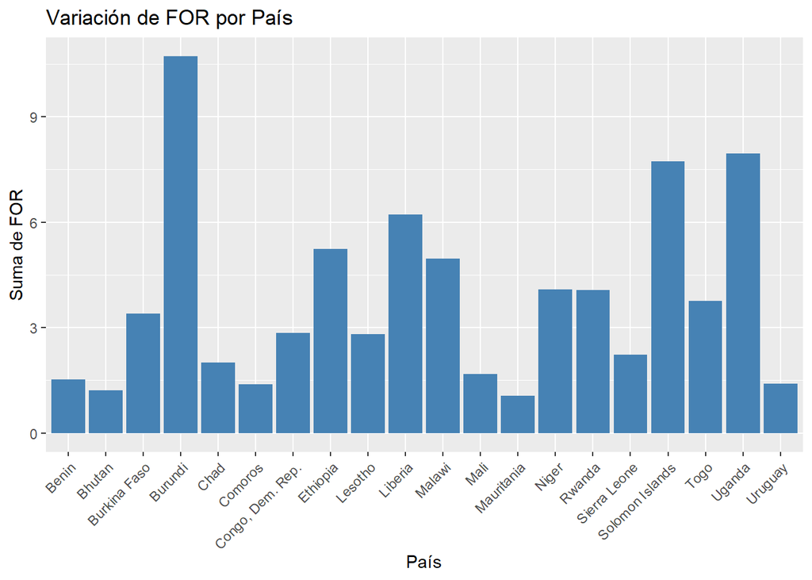

```r
dt4 <- worldSustainabiltyDataSet %>%
  rename(FOR = NY.ADJ.DFOR.GN.ZS) %>%
  filter(Year == 2018)

dt4_Grf <- dt4 %>% group_by(Country) %>% summarise(Total_FOR = sum(FOR, na.rm = TRUE)) %>% ungroup()

dt4_Grf <- dt4_Grf %>% arrange(desc(Total_FOR))


ggplot(head(dt4_Grf,20), aes(x = Country, y = Total_FOR)) +
  geom_col(fill = "steelblue") + # Usa geom_col para barras de valores pre-calculados
  labs(
    title = "Variación de FOR por País",
    x = "País",
    y = "Suma de FOR" # Cambia la etiqueta si usas la media
  ) +
  # Gira las etiquetas del eje X para mayor legibilidad si hay muchos países
  theme(axis.text.x = element_text(angle = 45, hjust = 1))
```

```r
length(dt4$Country)
```

```
## [1] 173
```

## 4.2 Hipótesis

Teniendo la pregunta PR4:¿La proporción de países que cumplen con el objetivo de no agotamiento neto de bosques es mayor que 50 %?  
- n: Paises del mundo (173) - H0: p = 50 - H1: p > 50

## 4.3 Test

El test será aplicado en una población suficientemente grande por lo que se puede asumir una distribución normal, con una varianza desconocida puesto que la variable country es categórica y no numérica, por tanto usaremos un test Z para un Test Unilateral derecho.

## 4.4 Aplicación del Test

```r
dt4_exitos <- dt4 %>% filter(!is.na(FOR)) %>%
  mutate(
    Cumple_Objetivo = ifelse(FOR <= 0, 1, 0) # 1 si se cumple (agotamiento es <= 0), 0 si no se cumple (agotamiento es > 0)
  )

n <- length(dt4$FOR)
prop.test(
  x= sum(dt4_exitos$Cumple_Objetivo),
  n = n,
  p = 0.5, #El objetivo es el 50%
  alternative = "greater", # Test unilateral derecho
  correct = TRUE # Maxima precisión
)
```

```
##
##  1-sample proportions test with continuity correction
##
## data:  sum(dt4_exitos$Cumple_Objetivo) out of n, null probability 0.5
## X-squared = 1.4798, df = 1, p-value = 0.1119
## alternative hypothesis: true p is greater than 0.5
## 95 percent confidence interval:
##  0.4837479 1.0000000
## sample estimates:
##         p
## 0.5491329
```

## 4.5 Desarrollo

```r
x <- sum(dt4_exitos$Cumple_Objetivo)
pobs <- x / n
p0 <- 0.5
# 1. Calcular el Error Estándar (SE) bajo H0
SE_H0 <- sqrt(p0 * (1 - p0) / n)

# 2. Calcular el Estadístico Z
numerador_z <- (pobs - p0) - (0.5 / n)
Z_calc <- numerador_z / SE_H0
pL <- pobs - Z_calc*SE_H0
pU <- pobs + Z_calc*SE_H0

# 3. Calcular el Valor p para el Test UNILATERAL DERECHO
pvalue_final <- pnorm(Z_calc, lower.tail = FALSE)

# --- Output Final (Z_corr y PValue) ---
resultados_finales <- c(
  round(Z_calc, 6),
  round(pvalue_final, 6)
)
names(resultados_finales) <- c("Zobs (Corregido)", "PValue (Corregido)")

print(resultados_finales)
```

```
##   Zobs (Corregido) PValue (Corregido)
##           1.216457           0.111905
```

## 4.6 Resultados

```r
resultados_Z_manual <- c( round(Z_calc, 6), pL, pU, round(pvalue_final,4))
names(resultados_Z_manual) <- c("Zobs", "Limite Inferior", "Limite Superior", "PValue")

print(resultados_Z_manual)
```

```
##            Zobs Limite Inferior Limite Superior          PValue
##       1.2164570       0.5028902       0.5953757       0.1119000
```

# 5 Conclusiones y comunicación del resultados

| Pregunta de Investigación | Tipo de Test | Hipótesis Nula | Hipótesis Alternativa | Valor p Obtenido | Decisión e Interpretación (alpha=0.05) |
| --- | --- | --- | --- | --- | --- |
| 1. Esperanza de Vida (LE) | Test t de Welch (Dos Muestras, sigma^2 distintas) | H0: mu1 = mu2 | H1: mu1 > mu2 (mu1 = Alto Ingreso) | ~ < 2.2e-16 | **Rechazar H0**. El p-value es extremadamente pequeño. Se afirma que la esperanza de vida en países de alto ingreso es significativamente mayor que en el resto. |
| 2. Desigualdad (GINI) 2008 vs. 2018 | Test t para dos muestras (Varianzas iguales) | H0: mu2008 = mu2018 | H1: mu2008 > mu2018 (Reducción de desigualdad) | ~ 0.095584 | **No Rechazar H0**. El p-value es mayor que 0.05. No hay evidencia para afirmar que la desigualdad global se haya reducido significativamente. |
| 3. Desigualdad por Régimen | Test Exacto de Fisher (o Test Z para dos proporciones) | H0: pDem = pAut | H1: pDem != pAut (Proporción GINI > 40 es diferente) | ~ 1 (Fisher); 0.8905 (Z Manual) | **No Rechazar H0**. El p-value es muy alto. No se puede afirmar que la proporción de alta desigualdad sea diferente entre regímenes democráticos y autocráticos. |
| 4. Bosques (FOR) vs. 50% | Test Z para una proporción (con corrección de continuidad) | H0: p = 0.50 | H1: p > 0.50 (Proporción FOR <= 0 es mayor que 50%) | ~ 0.1119 | **No Rechazar H0**. El p-value es mayor que 0.05. No hay evidencia para afirmar que la proporción de países que cumplen el objetivo sea mayor al 50%. |